# Alkoholowi Romantycy

Hanna Zdulska & Jakub Wiśniewski

3/14/2020

# 1 Zbiór

## 1.1 Opis

Context:  
The data were obtained in a survey of students math and portuguese language courses in secondary school. It contains a lot of interesting social, gender and study information about students. You can use it for some EDA or try to predict students final grade.

Content:  
Attributes for both student-mat.csv (Math course) and student-por.csv (Portuguese language course) datasets:

**school** - student’s school (binary: ‘GP’ - Gabriel Pereira or ‘MS’ - Mousinho da Silveira)  
**sex** - student’s sex (binary: ‘F’ - female or ‘M’ - male)  
**age** - student’s age (numeric: from 15 to 22)  
**address** - student’s home address type (binary: ‘U’ - urban or ‘R’ - rural)  
**famsize** - family size (binary: ‘LE3’ - less or equal to 3 or ‘GT3’ - greater than 3)  
**Pstatus** - parent’s cohabitation status (binary: ‘T’ - living together or ‘A’ - apart)  
**Medu** - mother’s education (numeric: 0 - none, 1 - primary education (4th grade), 2 – 5th to 9th grade, 3 – secondary education or 4 – higher education)  
**Fedu** - father’s education (numeric: 0 - none, 1 - primary education (4th grade), 2 – 5th to 9th grade, 3 – secondary education or 4 – higher education)  
**Mjob** - mother’s job (nominal: ‘teacher’, ‘health’ care related, civil ‘services’ (e.g. administrative or police), ‘at_home’ or ‘other’)  
**Fjob** - father’s job (nominal: ‘teacher’, ‘health’ care related, civil ‘services’ (e.g. administrative or police), ‘at_home’ or ‘other’)  
**reason** - reason to choose this school (nominal: close to ‘home’, school ‘reputation’, ‘course’ preference or ‘other’)  
**guardian** - student’s guardian (nominal: ‘mother’, ‘father’ or ‘other’)  
**traveltime** - home to school travel time (numeric: 1 - 1 hour)  
**studytime** - weekly study time (numeric: 1 - 10 hours)  
**failures** - number of past class failures (numeric: n if 1<=n<3, else 4)  
**schoolsup** - extra educational support (binary: yes or no)  
**famsup** - family educational support (binary: yes or no)  
**paid** - extra paid classes within the course subject (Math or Portuguese) (binary: yes or no)  
**activities** - extra-curricular activities (binary: yes or no)  
**nursery** - attended nursery school (binary: yes or no)  
**higher** - wants to take higher education (binary: yes or no)  
**internet** - Internet access at home (binary: yes or no)  
**romantic** - with a romantic relationship (binary: yes or no)  
**famrel** - quality of family relationships (numeric: from 1 - very bad to 5 - excellent)  
**freetime** - free time after school (numeric: from 1 - very low to 5 - very high)  
**goout** - going out with friends (numeric: from 1 - very low to 5 - very high)  
**Dalc** - workday alcohol consumption (numeric: from 1 - very low to 5 - very high)  
**Walc** - weekend alcohol consumption (numeric: from 1 - very low to 5 - very high)  
**health** - current health status (numeric: from 1 - very bad to 5 - very good)  
**absences** - number of school absences (numeric: from 0 to 93)

These grades are related with the course subject, Math or Portuguese:

**G1** - first period grade (numeric: from 0 to 20)  
**G2** - second period grade (numeric: from 0 to 20) **G3** - final grade (numeric: from 0 to 20, output target)

Source Information  
P. Cortez and A. Silva. Using Data Mining to Predict Secondary School Student Performance. In A. Brito and J. Teixeira Eds., Proceedings of 5th FUture BUsiness TEChnology Conference (FUBUTEC 2008) pp. 5-12, Porto, Portugal, April, 2008, EUROSIS, ISBN 978-9077381-39-7.

Fabio Pagnotta, Hossain Mohammad Amran.  
Email:fabio.pagnotta@studenti.unicam.it, mohammadamra.hossain ‘@’ studenti.unicam.it  
University Of Camerino

```r
options(stringsAsFactors = F)
library(DataExplorer)
library(ggplot2)
library(patchwork)
library(dplyr)
library(DT)
df <- read.csv("./students-all.csv")
df <- df %>% select(-X)

# to make procentowa tabelka
ptable <- function(s1, s2){
  tab <- table(df[,c(s1,s2)])
  as.data.frame(prop.table(tab, 1)*100)
}
```

## 1.2 Eksploracja

```r
slices <- which(colnames(df)  %in% c("age", "failures", "absences", "G1", "G2", "G3"))
df[, -slices] <- lapply(df[, -slices], as.factor)
head(df)
```

|  | school | sex | age | address | famsize | Pstatus | Medu | Fedu | Mjob | Fjob | reason | guardian | traveltime | studytime | failures | schoolsup | famsup | paid | activities | nursery | higher | internet | romantic | famrel | freetime | goout | Dalc | Walc | health | … |
| --- | --- | --- | --- | --- | --- | --- | --- | --- | --- | --- | --- | --- | --- | --- | --- | --- | --- | --- | --- | --- | --- | --- | --- | --- | --- | --- | --- | --- | --- | --- |
| 1 | GP | F | 18 | U | GT3 | A | 4 | 4 | at_home | teacher | course | mother | 2 | 2 | 0 | yes | no | no | no | yes | yes | no | no | 4 | 3 | 4 | 1 | 1 | 3 | … |
| 2 | GP | F | 17 | U | GT3 | T | 1 | 1 | at_home | other | course | father | 1 | 2 | 0 | no | yes | no | no | no | yes | yes | no | 5 | 3 | 3 | 1 | 1 | 3 | … |
| 3 | GP | F | 15 | U | LE3 | T | 1 | 1 | at_home | other | other | mother | 1 | 2 | 3 | yes | no | yes | no | yes | yes | yes | no | 4 | 3 | 2 | 2 | 3 | 3 | … |
| 4 | GP | F | 15 | U | GT3 | T | 4 | 2 | health | services | home | mother | 1 | 3 | 0 | no | yes | yes | yes | yes | yes | yes | yes | 3 | 2 | 2 | 1 | 1 | 5 | … |
| 5 | GP | F | 16 | U | GT3 | T | 3 | 3 | other | other | home | father | 1 | 2 | 0 | no | yes | yes | no | yes | yes | no | no | 4 | 3 | 2 | 1 | 2 | 5 | … |
| 6 | GP | M | 16 | U | LE3 | T | 4 | 3 | services | other | reputation | mother | 1 | 2 | 0 | no | yes | yes | yes | yes | yes | yes | no | 5 | 4 | 2 | 1 | 2 | 5 | … |

Większość kolumn jest w postaci zmiennych o rozkładzie dyskretnym. Jest tak dlatego, że dane zostały zebrane w postaci ankiet, na których studenci mieli kilka opcji do wyboru.

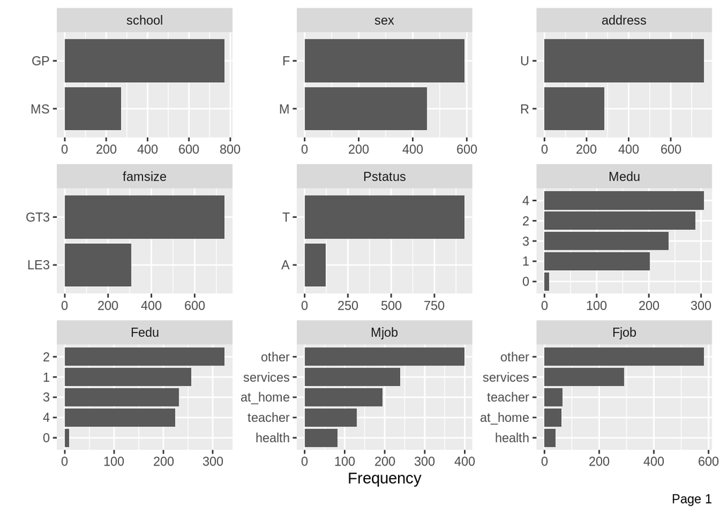

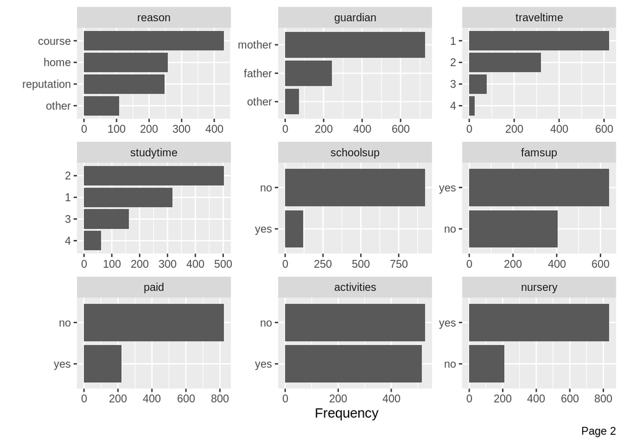

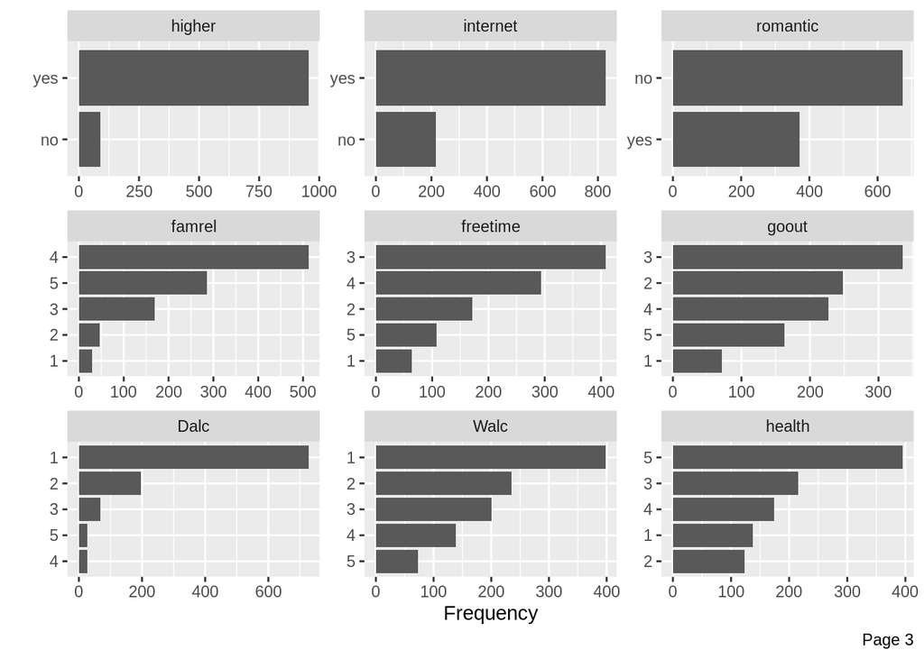

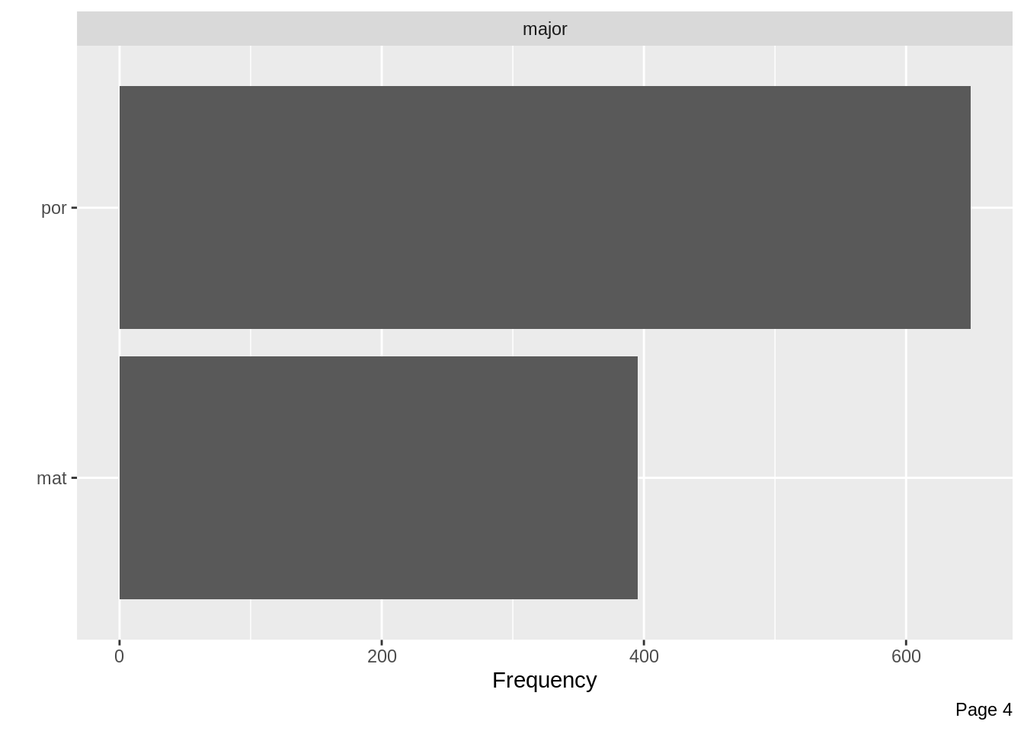

```r
DataExplorer::plot_bar(df)
```

Ze zmiennymi ciągłymi jest nieco inaczej. Dla każdej zmiennej możemy wyróżnić kilka-kilkanaście unikatowych wartości.

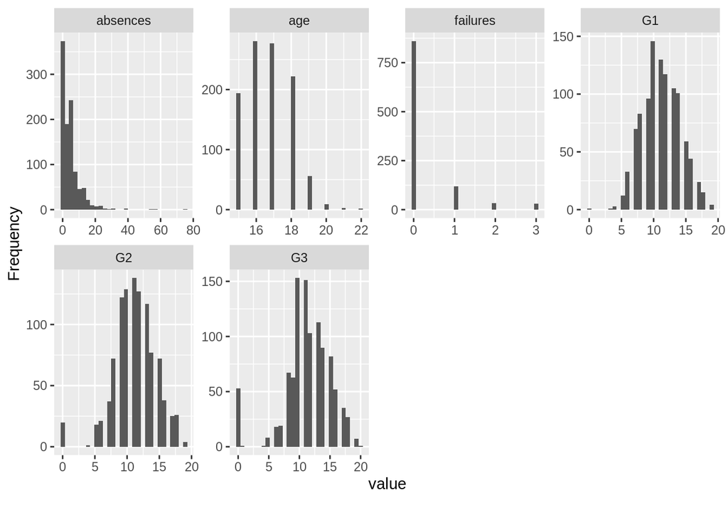

```r
DataExplorer::plot_histogram(df)
```

Tak prezentują się zaś gęstości zmiennych ciągłych. Najbardziej podobne do rozkładu normalnego są G1, G2 i G3.

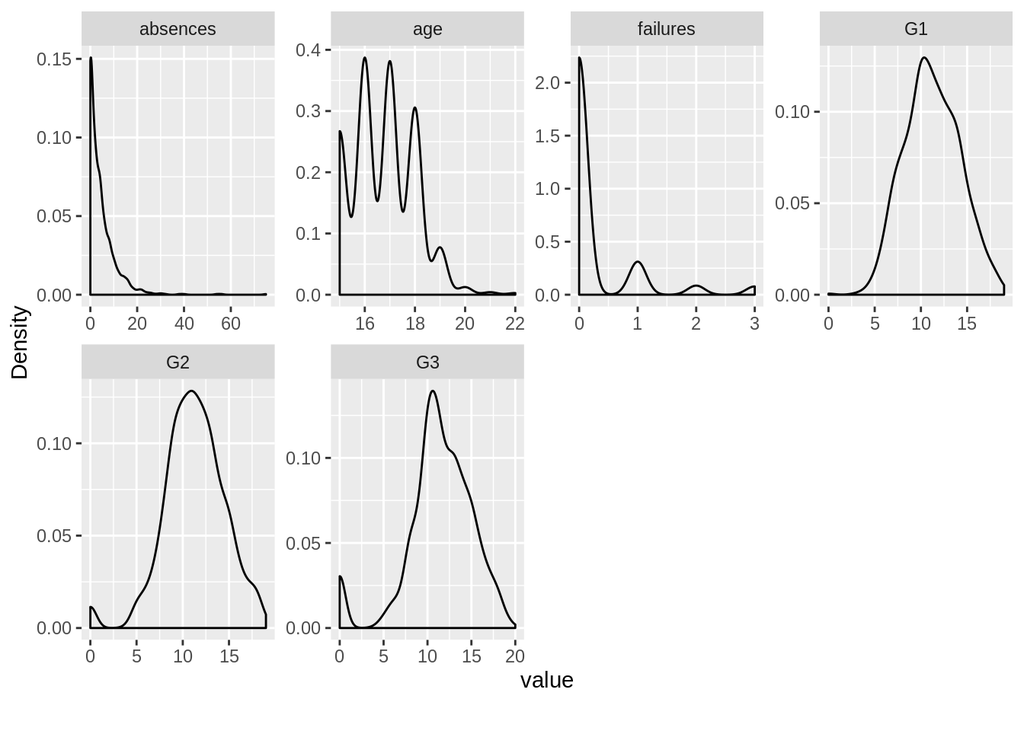

```r
DataExplorer::plot_density(df)
```

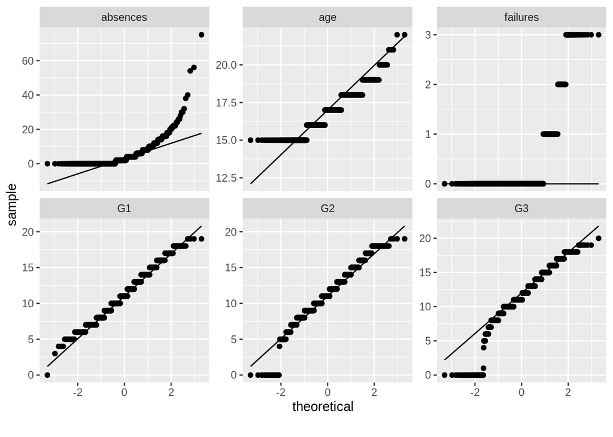

```r
DataExplorer::plot_qq(df)
```

Popatrzmy teraz przez pryzmat zmiennej `romantic` oznaczającej czy osoba jest w związku. Zwróćmy uwagę na wykres w stosunku do wieku. Mediana wieku osób będących w związku przewyższa o około rok medianę wieku osób niebędących w związku. Możemy dopatrzeć się również delikatnie lepszych wyników końcowych (G3) osób niebędących w związku.

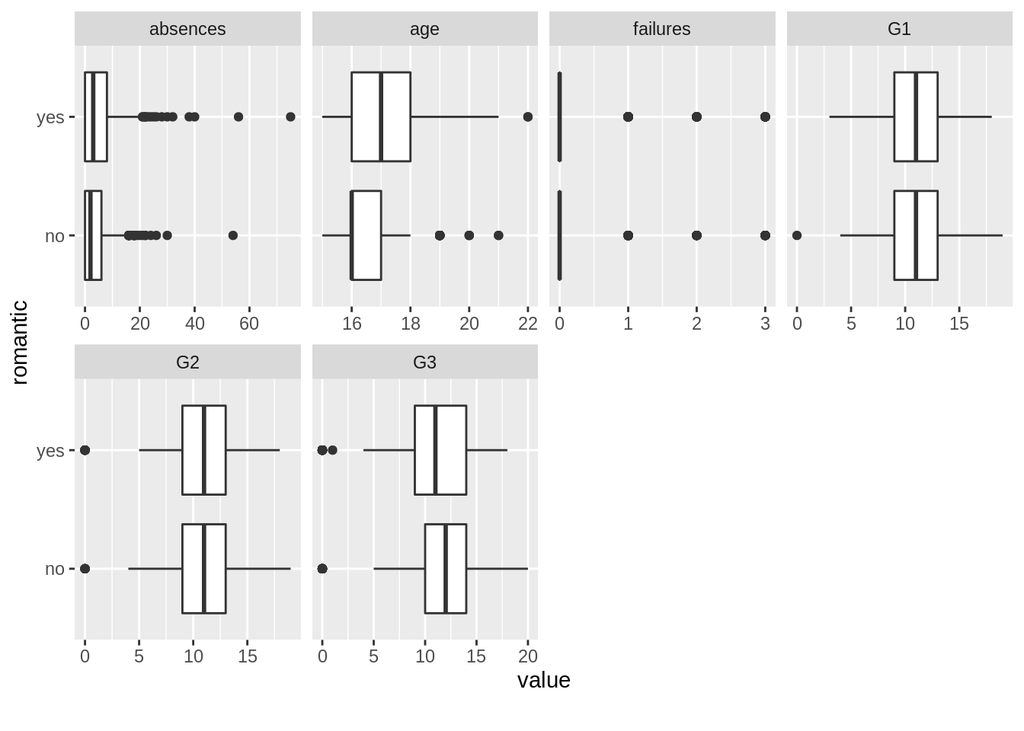

```r
DataExplorer::plot_boxplot(df, by = "romantic")
```

Kto mało pije w weekendy ten w tygodniu też mało pije. Czy wszyscy? Wśród osób które piją więcej w tygodniu, a mniej na weekendzie są prawie wyłącznie osoby w związku! Poza tym widzimy, że studenci wolą konsumować alkohol podczas weekendu.

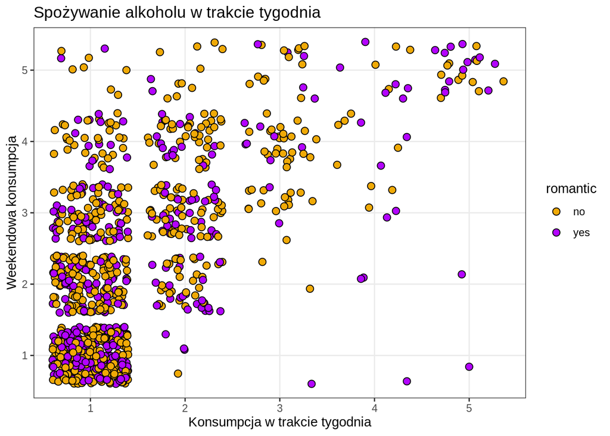

```r
# tendencja do picia w weekendy, ale wytrywali romantycy w [4,5] Dalc
ggplot(df, aes(x = Dalc, y=Walc, fill = romantic)) + geom_jitter(shape =21, size = 2.5) +
  scale_fill_manual(values = c("#f0aa07", "#b303ff"  )) + theme_bw() + ylab("Weekendowa konsumpcja") + xlab("Konsumpcja w trakcie tygodnia") + ggtitle("Spożywanie alkoholu w trakcie tygodnia")
```

Zwróćmy uwagę na ogony rozkładów. Osoby w związku częśniej dostają skrajnie złe wyniki i żadziej skrajnie dobre. Czy miłość jest barierą do dobrych wyników w nauce?

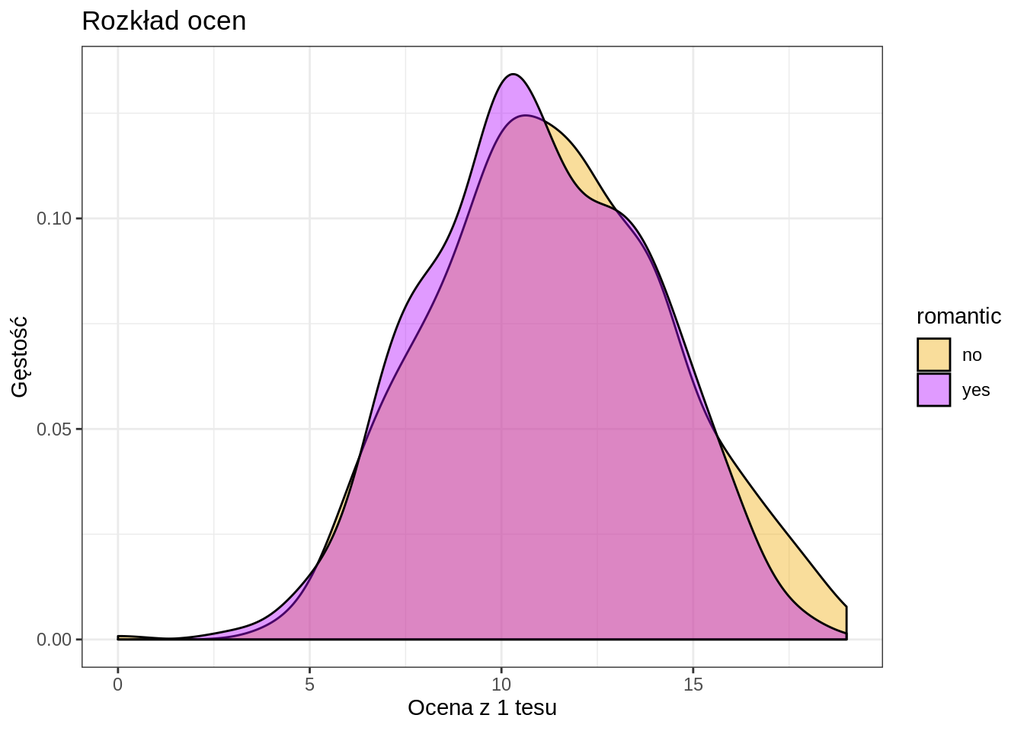

```r
# rozkład wyników w zależności od związku
ggplot(df, aes(x = G1, fill = romantic)) + geom_density(alpha = 0.4) + scale_fill_manual(values = c("#f0aa07", "#b303ff"  )) +
  theme_bw() + xlab("Ocena z 1 tesu") + ylab("Gęstość") + ggtitle("Rozkład ocen")
```

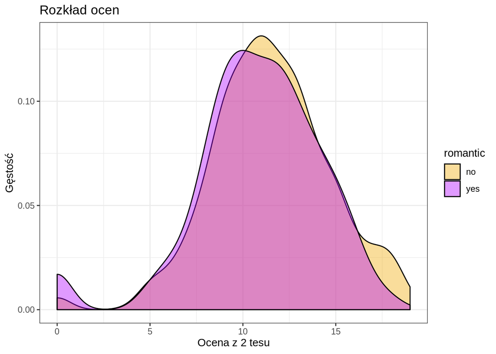

```r
ggplot(df, aes(x = G2, fill = romantic)) + geom_density(alpha = 0.4) + scale_fill_manual(values = c("#f0aa07", "#b303ff"  )) +
  theme_bw() + xlab("Ocena z 2 tesu") + ylab("Gęstość") + ggtitle("Rozkład ocen")
```

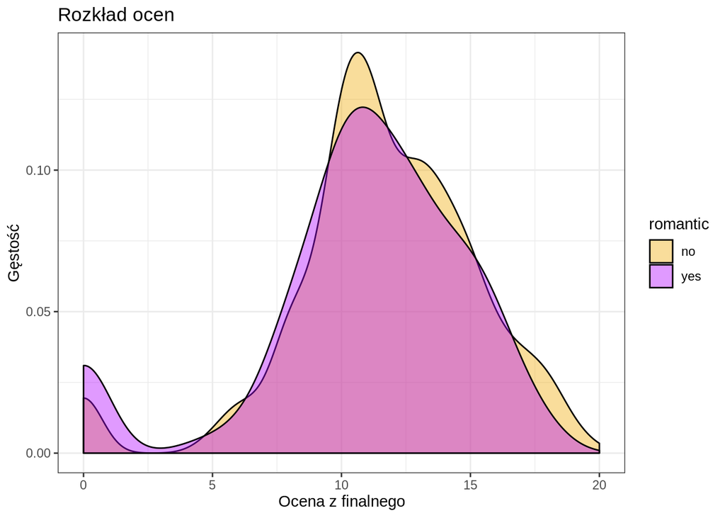

```r
ggplot(df, aes(x = G3, fill = romantic)) + geom_density(alpha = 0.4) + scale_fill_manual(values = c("#f0aa07", "#b303ff"  ))+
  theme_bw() + xlab("Ocena z finalnego") + ylab("Gęstość") + ggtitle("Rozkład ocen")
```

Kto pije więcej? Tutaj nie ma zwyzięzcy, chociaż wśród osób pijących w weekendy najwięcej jest większy odsetek osób w związku.

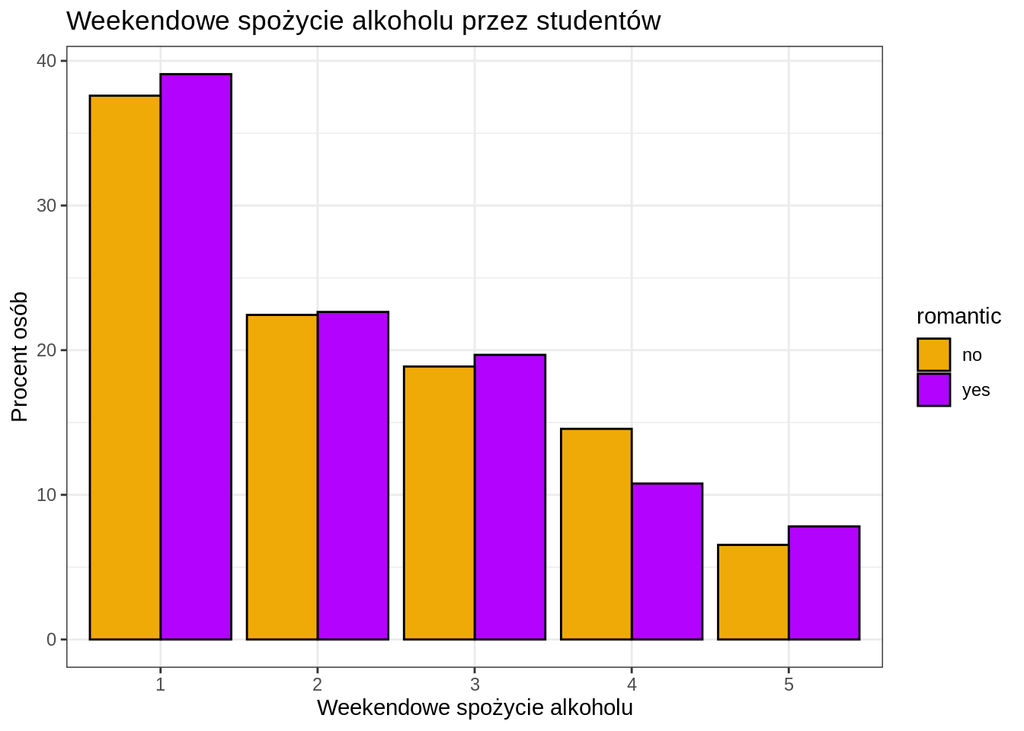

```r
# kto pije więcej procentowo ?
tab <- table(df[,c("romantic", "Walc")])
x <- as.data.frame(prop.table(tab, 1)*100)
ggplot(x, aes(x = Walc, y = Freq, fill = romantic)) + geom_bar(position = "dodge", stat = "identity", color = "black") + ylab("Procent osób") + theme_bw() + xlab("Weekendowe spożycie alkoholu") +
  ggtitle("Weekendowe spożycie alkoholu przez studentów") +
  scale_fill_manual(values = c("#f0aa07", "#b303ff"  ))
```

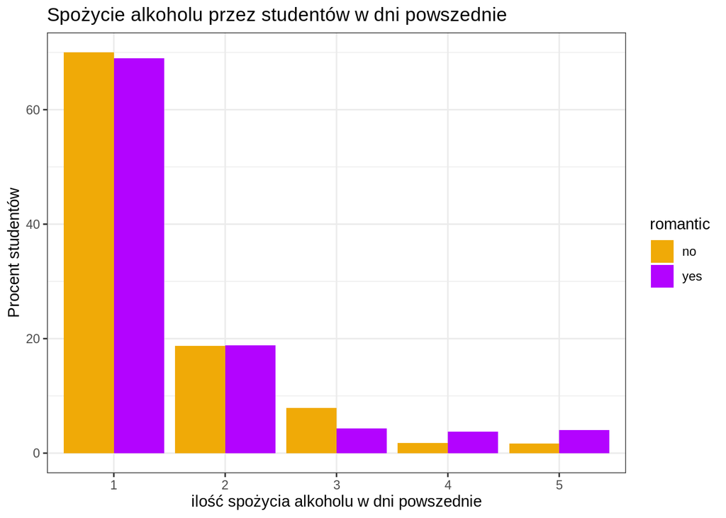

```r
# a w normalne dni?
tab <- table(df[,c("romantic", "Dalc")])
x <- as.data.frame(prop.table(tab, 1)*100)
ggplot(x, aes(x = Dalc, y = Freq, fill = romantic)) + geom_bar(position = "dodge", stat = "identity") + scale_fill_manual(values = c("#f0aa07", "#b303ff"  )) + theme_bw() + xlab("ilość spożycia alkoholu w dni powszednie") + ylab("Procent studentów") + ggtitle("Spożycie alkoholu przez studentów w dni powszednie")
```

Dodajmy teraz weekendową konsumpcję do tej tygodniowej. Na tym wykresie widzimy liczbę osób, nie odsetek.

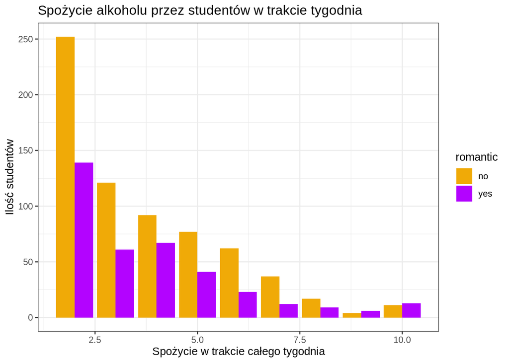

```r
# A łącznie? wg ludzi (sumarycznie Walc + Dalc)
ggplot(df, aes(x = as.integer(Walc) + as.integer(Dalc), fill = romantic )) + geom_bar(position = "dodge") +
  scale_fill_manual(values = c("#f0aa07", "#b303ff"  )) + theme_bw() + xlab("Spożycie w trakcie całego tygodnia") + ylab("Ilość studentów") + ggtitle("Spożycie alkoholu przez studentów w trakcie tygodnia")
```

Gdy popatrzymy na wykres procentowy, możemy jedynie utwierdzić się w przekonaniu, że osoby pijące najwięcej to osoby w związku.

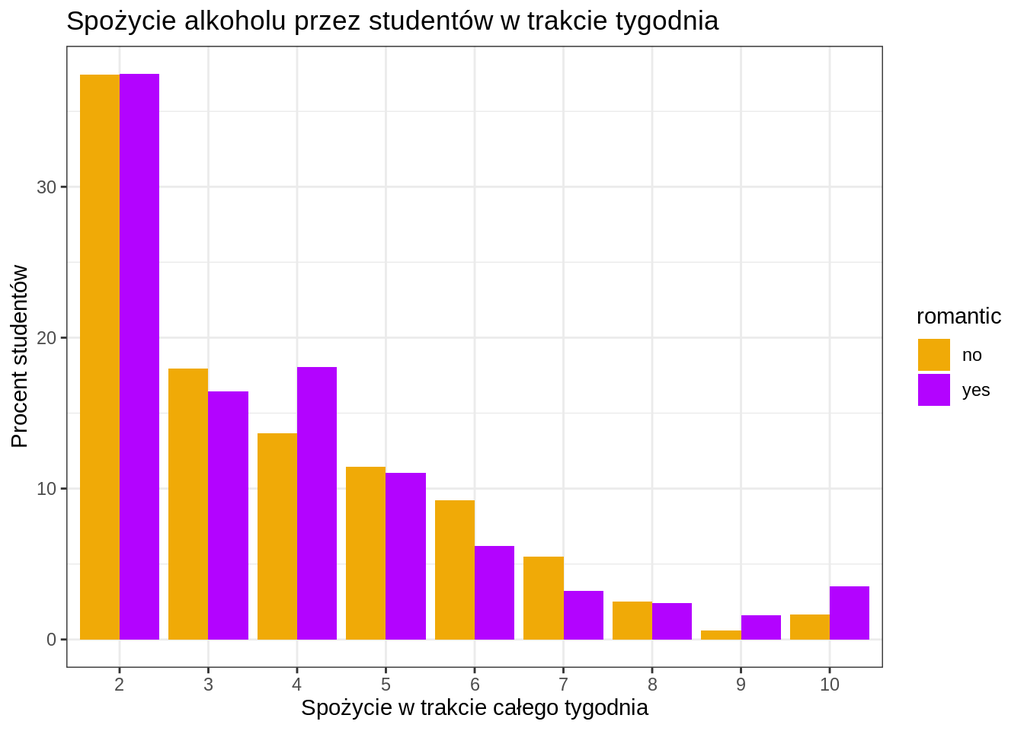

```r
df2 <- df %>%
  group_by(romantic) %>%
  transmute(alc = as.integer(Dalc) + as.integer(Walc))
x <- as.data.frame(prop.table(table(df2), 1)*100)

# procentowo
ggplot(x, aes(x = alc, y = Freq, fill = romantic)) + geom_bar(position = "dodge", stat = "identity") +
  scale_fill_manual(values = c("#f0aa07", "#b303ff"  )) + theme_bw() + xlab("Spożycie w trakcie całego tygodnia") + ylab("Procent studentów") + ggtitle("Spożycie alkoholu przez studentów w trakcie tygodnia")
```

A jak to wygląda dla poszczególnych kierunków? Z tego wykresu możemy jedynie wyczytać, że matematyka jest mniej popularnym kierunkiem.

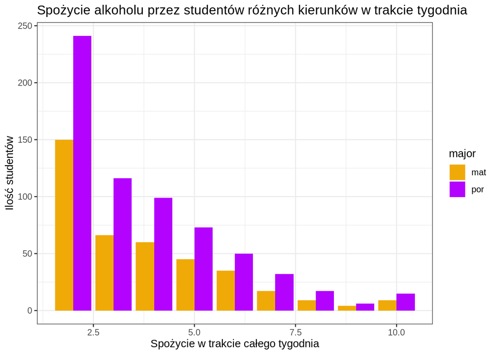

```r
# A w zależności od kierunku? wg ludzi (sumarycznie Walc + Dalc)
ggplot(df, aes(x = as.integer(Walc) + as.integer(Dalc), fill = major )) + geom_bar(position = "dodge") + scale_fill_manual(values = c("#f0aa07", "#b303ff"  )) + theme_bw() + xlab("Spożycie w trakcie całego tygodnia") + ylab("Ilość studentów") + ggtitle("Spożycie alkoholu przez studentów różnych kierunków w trakcie tygodnia")
```

Gdy popatrzymy na odsetki dla poszczególnych kierunków, nie będziemy widzieć większych różnic.

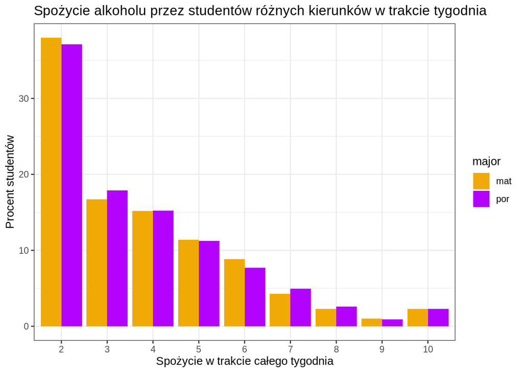

```r
df2 <- df %>%
  group_by(major) %>%
  transmute(alc = as.integer(Dalc) + as.integer(Walc))
x <- as.data.frame(prop.table(table(df2), 1)*100)

# procentowo
ggplot(x, aes(x = alc, y = Freq, fill = major)) + geom_bar(position = "dodge", stat = "identity") +
  scale_fill_manual(values = c("#f0aa07", "#b303ff"  )) + theme_bw() + xlab("Spożycie w trakcie całego tygodnia") + ylab("Procent studentów") + ggtitle("Spożycie alkoholu przez studentów różnych kierunków w trakcie tygodnia")
```

Wróćmy do naszych romantyków. Spójrzmy na osoby w związku i ich nieobecności na różnych kierunkach.

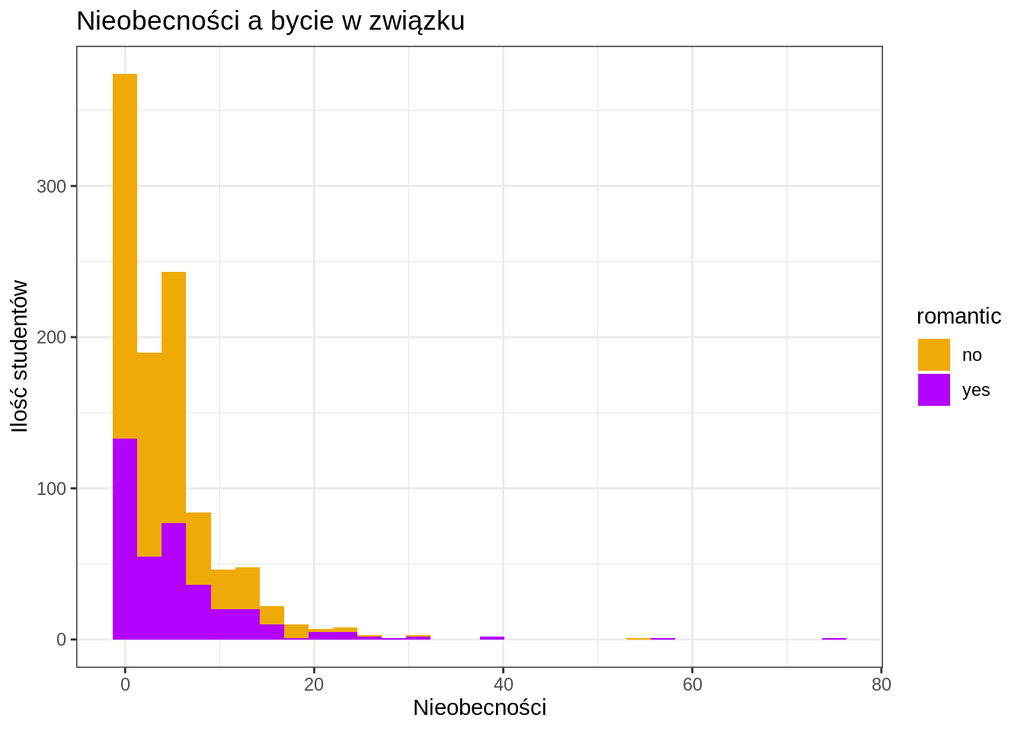

```r
ggplot(df, aes(absences, fill = romantic)) + geom_histogram() + scale_fill_manual(values = c("#f0aa07", "#b303ff"  )) + theme_bw() + xlab("Nieobecności") + ylab("Ilość studentów") + ggtitle("Nieobecności a bycie w związku")
```

Spójrzmy na “outliery”, osoby mające więcej niż 20 nieobecności to prawie w większości osoby w związku.

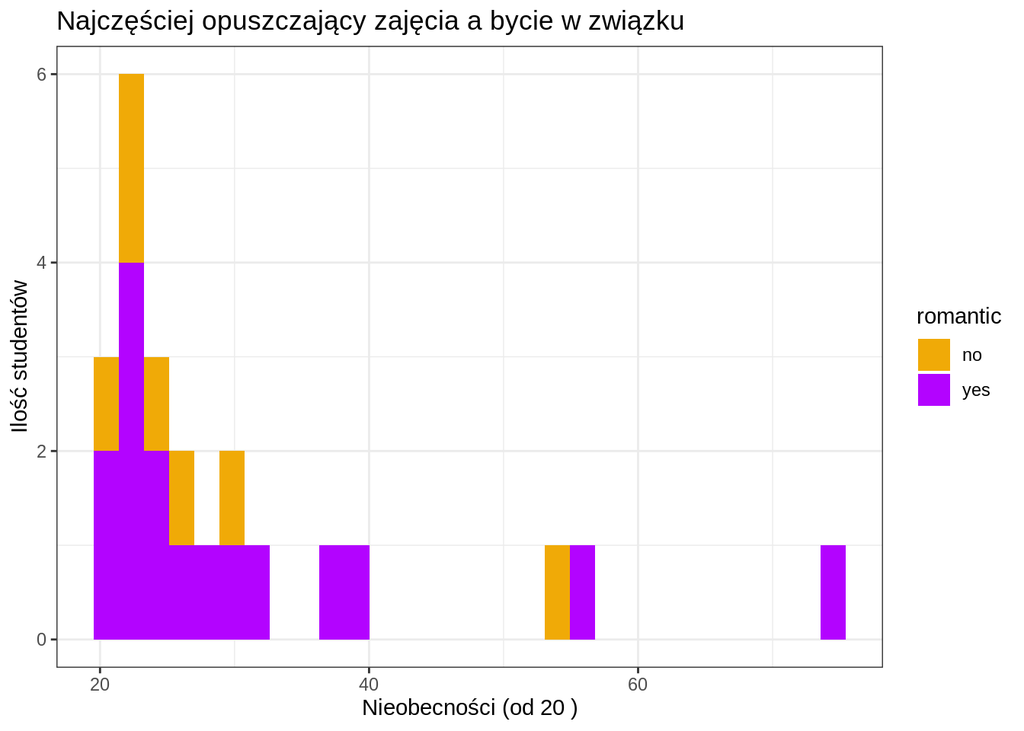

```r
ggplot(df[df$absences >20, ], aes(absences, fill = romantic)) + geom_histogram()  + scale_fill_manual(values = c("#f0aa07", "#b303ff"  )) + theme_bw() + xlab("Nieobecności (od 20 )") + ylab("Ilość studentów") + ggtitle("Najczęściej opuszczający zajęcia a bycie w związku")
```

To osoby w związku częściej opuszczają zajęcia. Szczególnie wśród matematyków. Zauważmy, że osoby deklarujące dużą(4) konsumpcję alkoholu w weekendy najczęściej opuszczają zajęcia! A jeszcze więcej osoby w związku. Dodatkowo im mniej student pije, tym częściej chodzi na zajęcia.

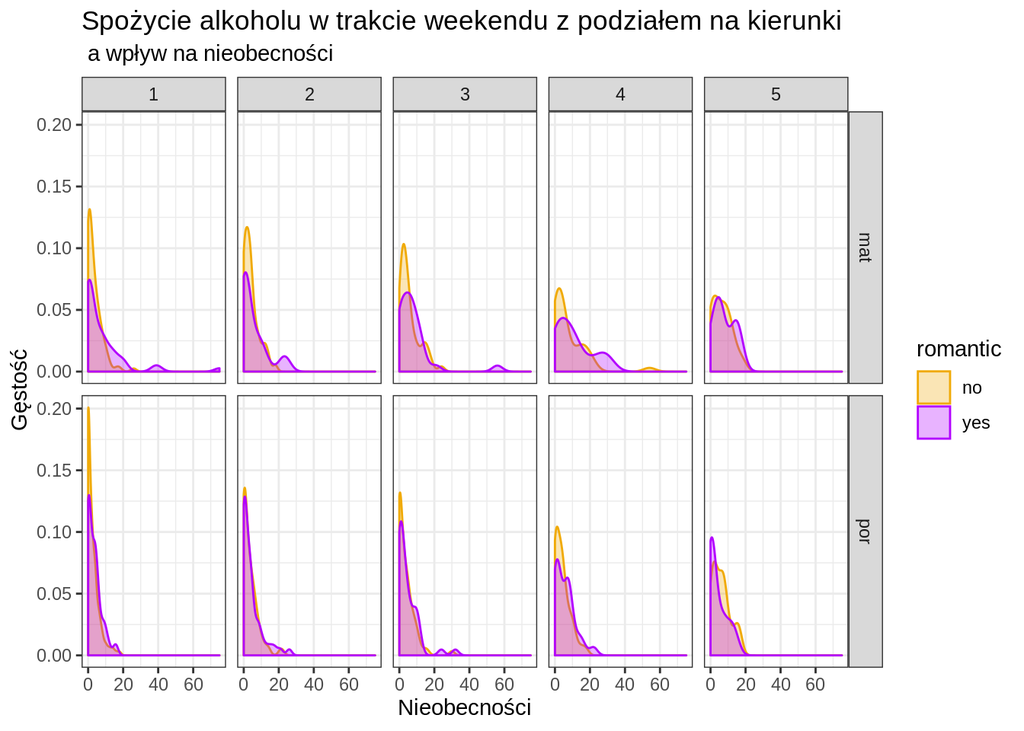

```r
# to może mają więcej nieobecności
ggplot(df, aes(x = absences, color = romantic, fill = romantic)) + geom_density(alpha = 0.3) + facet_grid(major~Walc) + scale_fill_manual(values = c("#f0aa07", "#b303ff"  )) + theme_bw() + xlab("Nieobecności") + ylab("Gęstość") + ggtitle("Spożycie alkoholu w trakcie weekendu z podziałem na kierunki" , subtitle =" a wpływ na nieobecności" ) + scale_color_manual(values = c("#f0aa07", "#b303ff"  ))
```

```r
# no i jakby ci bardziej pijani mieli więcej nieobecności
# ale czy to jesy wystarczająca próbka? Może jest tylko po 3 osoby pijące na lvl5?
table(df[,c("major", "Walc")])
```

```
##      Walc
## major   1   2   3   4   5
##   mat 151  85  80  51  28
##   por 247 150 120  87  45
```

[figure not shown]

```r
# A w Dalc?
ggplot(df, aes(x = absences, fill = romantic, color = romantic)) + geom_density(alpha = 0.3) + facet_grid(major~Dalc) + facet_grid(major~Walc) + scale_fill_manual(values = c("#f0aa07", "#b303ff"  )) + theme_bw() + xlab("Nieobecności") + ylab("Gęstość") + ggtitle("Spożycie alkoholu w trakcie tygodnia z podziałem na kierunki" , subtitle =" a wpływ na nieobecności" ) + scale_color_manual(values = c("#f0aa07", "#b303ff"  ))
```

```r
table(df[,c("major", "Dalc")])
```

```
##      Dalc
## major   1   2   3   4   5
##   mat 276  75  26   9   9
##   por 451 121  43  17  17
```

[figure not shown]

```r
# to może gdzie mieszkają ma wpływ?
ggplot(df, aes(G3, color = romantic, fill = romantic)) + geom_density(alpha= 0.4)  + scale_fill_manual(values = c("#f0aa07", "#b303ff"  )) + theme_bw() + xlab("Finalna ocena") + ylab("Gęstość") + ggtitle("Wpływ miejsca zamieszkania na oceny") + scale_color_manual(values = c("#f0aa07", "#b303ff"  ))
```

Czy picie ma jakiś związek na oceny?

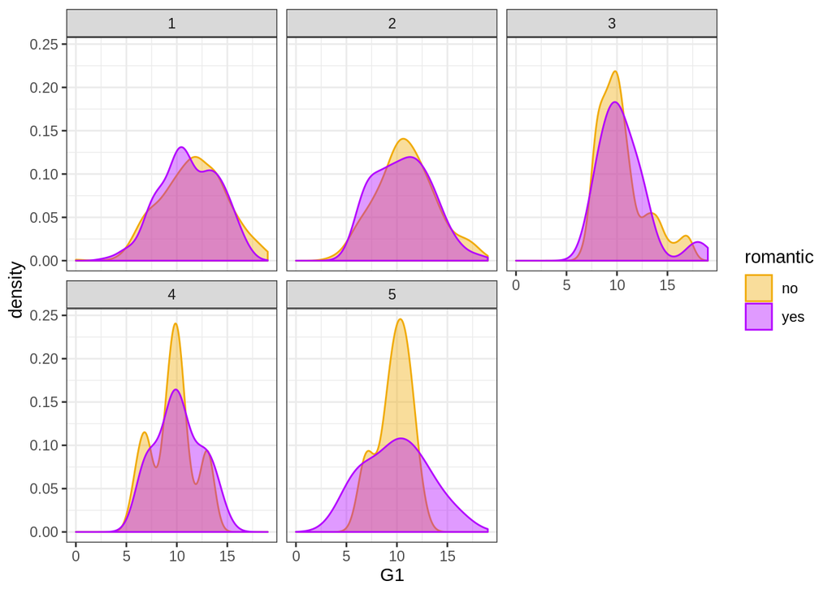

```r
# A jak picie w dniach tygodnia ma odbicie na ocenach?
ggplot(df, aes(G1, color = romantic, fill = romantic)) + geom_density(alpha = 0.4) + facet_wrap(~Dalc) + scale_fill_manual(values = c("#f0aa07", "#b303ff"  )) + theme_bw() + scale_color_manual(values = c("#f0aa07", "#b303ff"  ))
```

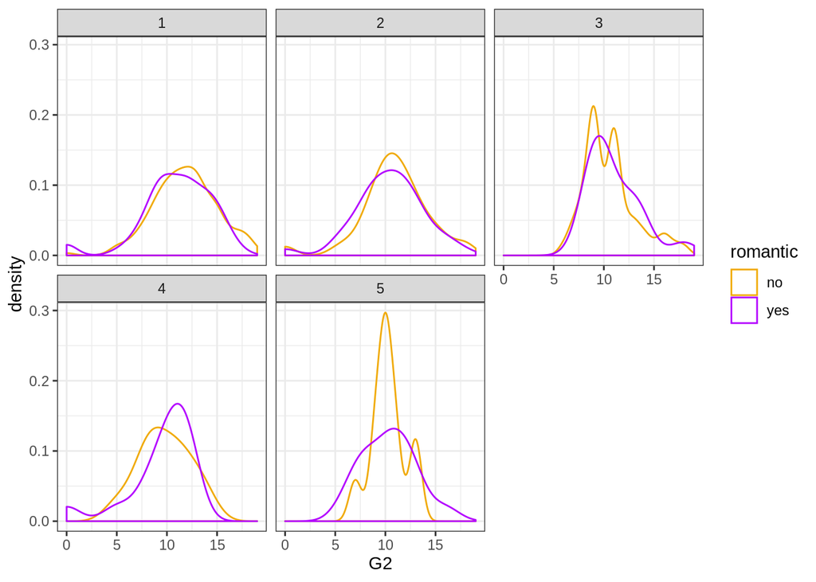

```r
ggplot(df, aes(G2, color = romantic)) + geom_density(alpha = 0.4) + facet_wrap(~Dalc)  + scale_fill_manual(values = c("#f0aa07", "#b303ff"  )) + theme_bw() + scale_color_manual(values = c("#f0aa07", "#b303ff"  ))
```

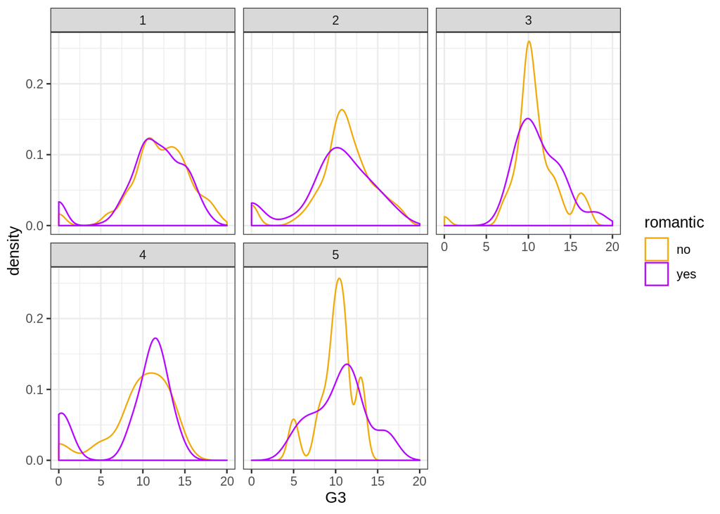

```r
ggplot(df, aes(G3, color = romantic)) + geom_density(alpha = 0.4) + facet_wrap(~Dalc)  + scale_fill_manual(values = c("#f0aa07", "#b303ff"  )) + theme_bw() + scale_color_manual(values = c("#f0aa07", "#b303ff"  ))
```

```r
# sprawdzmy próbkę
table(df[, c("Dalc", "romantic")])
```

```
##     romantic
## Dalc  no yes
##    1 471 256
##    2 126  70
##    3  53  16
##    4  12  14
##    5  11  15
```

Co ciekawe osoby w związku mają przy spadku liczby obecności nie doświadczają spadku ostatecznej oceny.

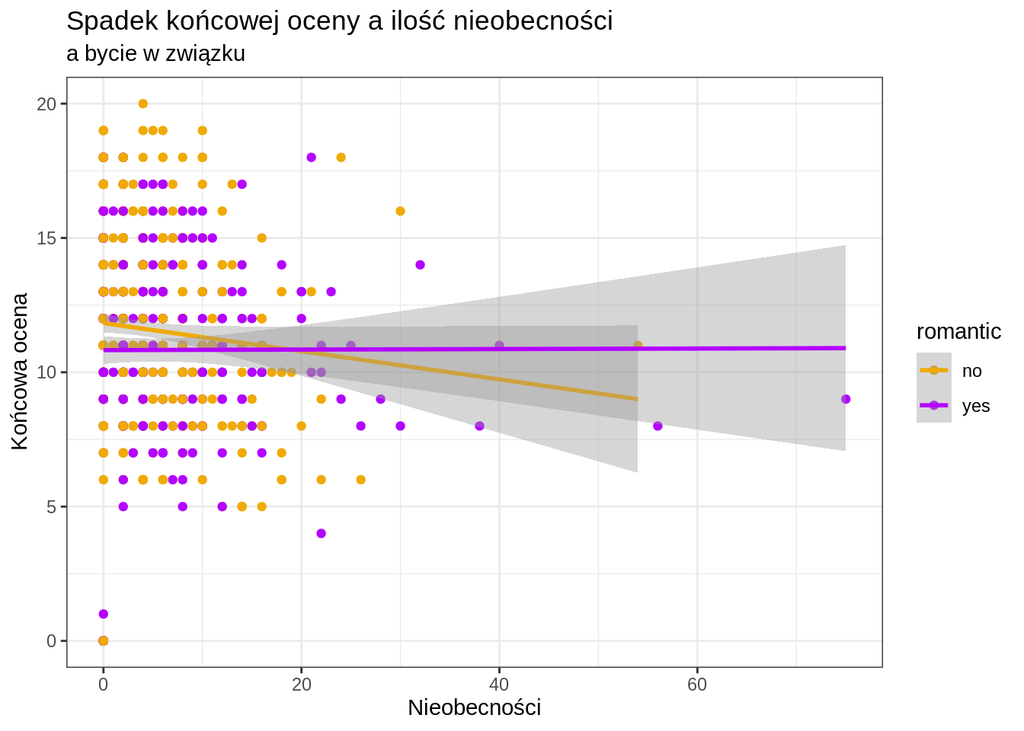

```r
ggplot(df, aes(x = absences, y = G3, color = romantic)) + geom_point() + geom_smooth(method = "lm") + theme_bw() + scale_color_manual(values = c("#f0aa07", "#b303ff"  ))   + ggtitle("Spadek końcowej oceny a ilość nieobecności" , subtitle = "a bycie w związku") + xlab("Nieobecności") + ylab("Końcowa ocena")
```